# Analysis of Incarceration and Race

Kaidi Chen

2/22/2022

## Introduction

In my report, I will examine the distribution of crime rates by state in the United States, the relationship between crime rates and population, and analyze the trends in crime rates by race over the 49 years from 1970 to 2018 based on the data loaded from Vera Institute. These research topics will mainly revolve around the variables of total population, total popution in jail, and the number of people in prisons of various ethnic groups. Definitely, these topics also need to include the two variables of state and year in the data.

## Summary information

I have used `nrow(data)` to find out the number of observations, which is `summary_info$num_observations`, and for the the number of variables `summary_info$num_variables` we used `ncol(data)`to obtain the output. The maximum population of black people in Washington prisons is stored in the variable `summary_info$max_pop_jail_black` .For the maximum population of white people in Washington prisons, the variable name is `summary_info$max_pop_jail_white`. Then for the the maximum population of Asian Americans and Pacific Islanders in Washington prisons, we have the independent variable `summary_info$max_pop_jail_aapi`, and we receive the the maximum population of latinx people in Washington prisons by `summary_info$max_pop_jail_latinx`.

According to the data, I can summarize that the number of observations for the total data is 153811 . The number of variavbles for the total data is 11 . The maximum population of black people in Washington prisons is 1055.51 , and the maximum population of white people in Washington prisons is 1997.8 ; The maximum population of Asian Americans and Pacific Islanders in Washington prisons is 174.33 , and the maximum population of latinx people in Washington prisons is 504 .

From the summary information, we can see that in Washington state, the crime rate of blacks and whites is still relatively high, and the maximum number of prisoners is far higher than the other two races, so we can think about whether race and crime rate are related.

## Chart1: Trends For Crime Rate of Different Races in US from 1970 to 2018

**Purpose:** Showing different lines represented different races, the graph implies the population in jail of different racial groups over time in US.

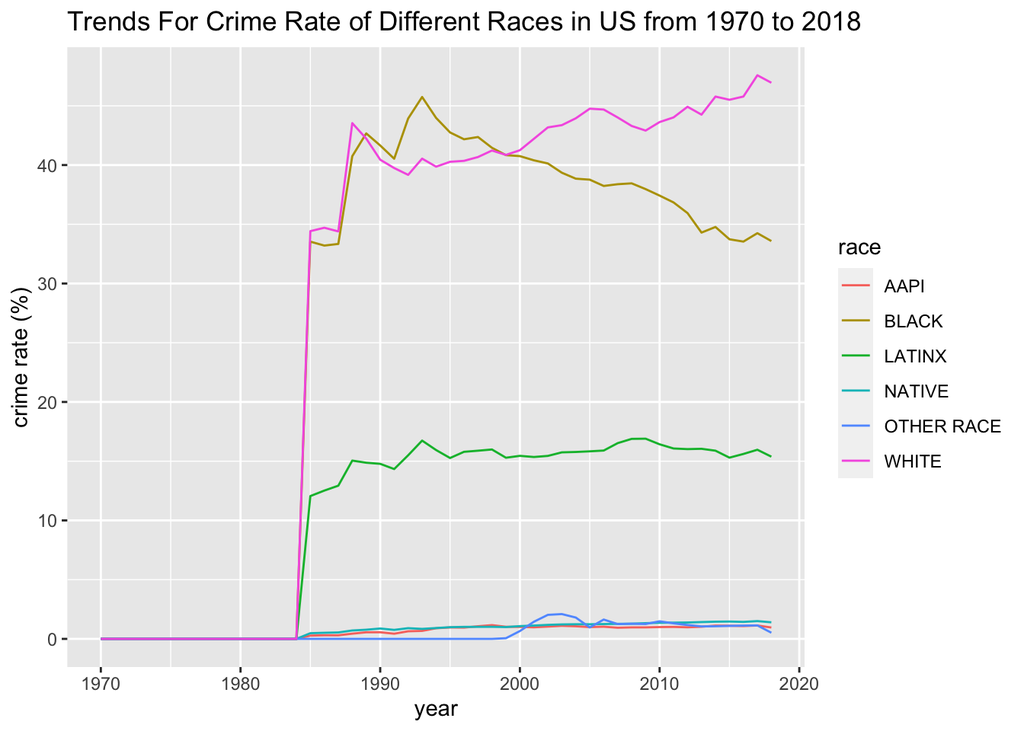

## Chart2: Relationship Between Jail Popultaion of White People and Jail Popultaion of Black People in US

**Purpose:** I use scatter plot to show how jail population of white people and jail population of black people in US are related to one another.

**Patterns:** I can see that as the number of whites in prisons increases, the number of blacks in prisons also increases, which means the two variables are positively correlated. Thus, I suggest that the contradiction may be due to the contradiction between the two races leading to mutual sentence, which also implies that there may be a problem of racial equality in society.

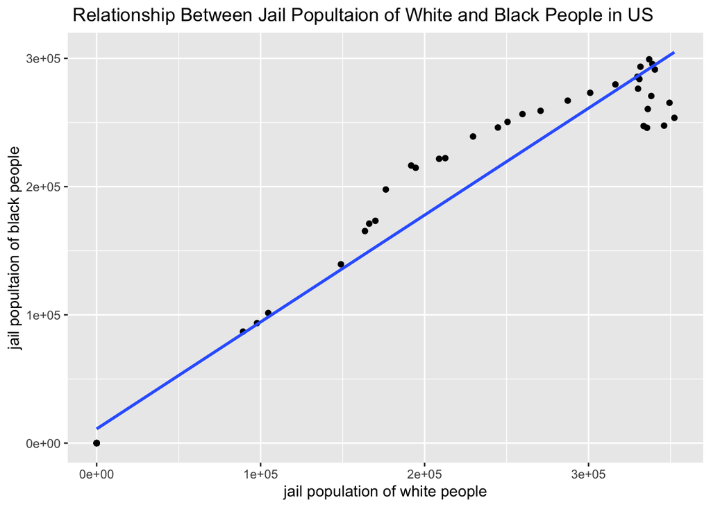

## Chart3: Total Jail Population compare Across Different States in 2018 in US

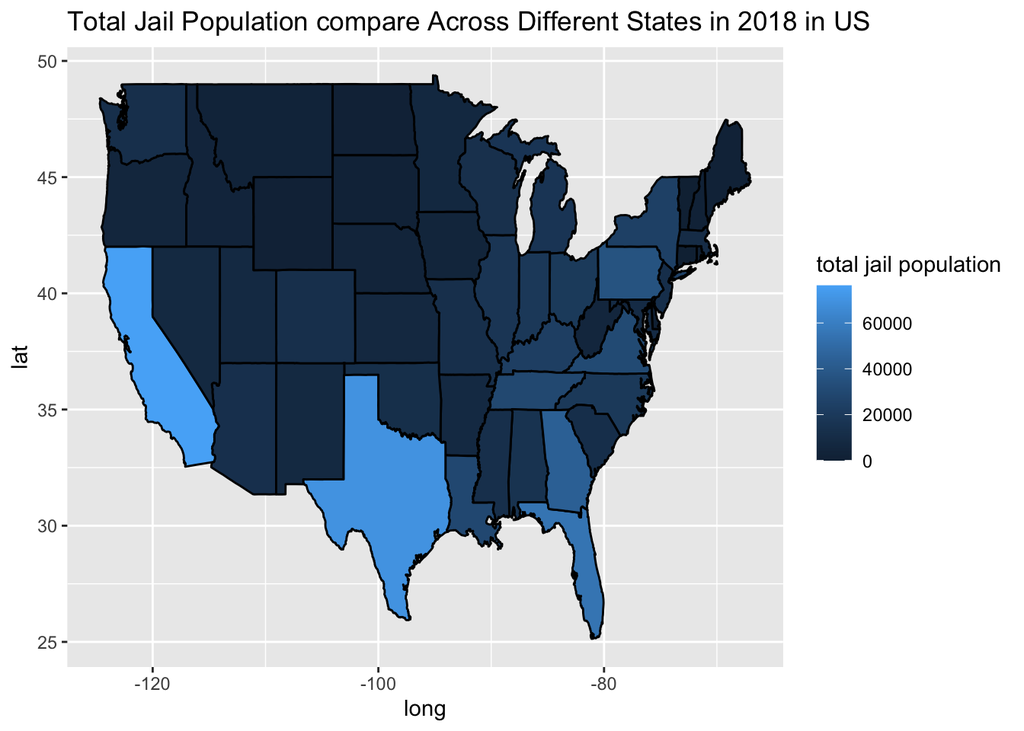